# Biological Examples

Ryan Franckowiak

January 30, 2019

### Load Required Libraries

```r
library(plyr)
library(dplyr)
library(FSA)
library(PerformanceAnalytics)
library(psych)
library(car)
library(rcompanion)
library(lmtest)
library(aod)
library(Amelia)
library(cvAUC)
```

### Bird introductions to New Zealand

In the 1800s, many people released their favorite bird species in New Zealand hoping that they would become established in the country. Veltman et al. (1996) assessed the success or failure (dependent variable) of these introduced species (n=79) based on 14 independent variables

Logistic regression can be used to predict the probability of success of a new introduction and assess which factors influence the success of these introductions. Once a model is developed it can be used to predict the success of future introductions.

```r
#Load New Zealand bird data file

Data.df<-read.csv("ZealandBirds.csv", header=TRUE)
Data.df
```

```
##      Species Status Length   Mass Range Migr Insect Diet Clutch Broods
## 1   Cyg_olor      1   1520 9600.0  1.21    1     12    2    6.0      1
## 2   Cyg_atra      1   1250 5000.0  0.56    1      0    1    6.0      1
## 3   Cer_nova      1    870 3360.0  0.07    1      0    1    4.0      1
## 4   Ans_caer      0    720 2517.0  1.10    3     12    2    3.8      1
## 5   Ans_anse      0    820 3170.0  3.45    3      0    1    5.9      1
## 6   Bra_cana      1    770 4390.0  2.96    2      0    1    5.9      1
## 7   Bra_sand      0     50 1930.0  0.01    1      0    1    4.0      2
## 8   Alo_aegy      0    680 2040.0  2.71    1     NA    2    8.5      1
## 9   Ana_plat      1    570 1020.0  9.01    2      6    2   12.6      1
## 10  Ana_acut      0    580  910.0  7.90    3      6    2    8.3      1
## 11  Ana_pene      0    480  590.0  4.33    3      0    1    8.7      1
## 12  Aix_spon      0    470  539.0  1.04    3     12    2   13.5      2
## 13  Ayt_feri      0    450  940.0  2.17    3     12    2    9.5      1
## 14  Ayt_fuli      0    435  684.0  4.81    3     12    2   10.1      1
```

[output cut: 145 more lines]

```r
#Only include variables that are numeric or can be made numeric

Data.num <-
   select(Data.df,
          Status,
          Length,
          Mass,
          Range,
          Migr,
          Insect,
          Diet,
          Clutch,
          Broods,
          Wood,
          Upland,
          Water,
          Release,
          Indiv)
```

```r
### Covert integer variables to numeric variables

Data.num$Status  = as.numeric(Data.num$Status)
Data.num$Length  = as.numeric(Data.num$Length)
Data.num$Migr    = as.numeric(Data.num$Migr)
Data.num$Insect  = as.numeric(Data.num$Insect)
Data.num$Diet    = as.numeric(Data.num$Diet)
Data.num$Broods  = as.numeric(Data.num$Broods)
Data.num$Wood    = as.numeric(Data.num$Wood)
Data.num$Upland  = as.numeric(Data.num$Upland)
Data.num$Water   = as.numeric(Data.num$Water)
Data.num$Release = as.numeric(Data.num$Release)
Data.num$Indiv   = as.numeric(Data.num$Indiv)

headtail(Data.num)
```

```
##     Status Length  Mass Range Migr Insect Diet Clutch Broods Wood Upland
## 1        1   1520  9600  1.21    1     12    2      6      1    0      0
## 2        1   1250  5000  0.56    1      0    1      6      1    0      0
## 3        1    870  3360  0.07    1      0    1      4      1    0      0
## 4        0    720  2517   1.1    3     12    2    3.8      1    0      0
## ...    ...    ...   ...   ...  ...    ...  ...    ...    ...  ...    ...
## 76       0    150  20.7  5.42    1     12    2    5.1      2    0      0
## 77       0    170    31  0.55    3     12    2      4   <NA>    1      0
## 78       0    210  36.9     2    2      8    2    3.7      1    0      0
## 79       0    225 106.5   1.2    2     12    2    4.8      2    0      0
##     Water Release Indiv
## 1       1       6    29
## 2       1      10    85
## 3       1       3     8
## 4       1       1    10
## ...   ...     ...   ...
## 76      1       2     9
## 77      0       1     2
## 78      1       1     2
## 79      0       1     2
```

```r
summary(Data.num)
```

```
##      Status           Length            Mass             Range
##  Min.   :0.0000   Min.   :  50.0   Min.   :  11.50   Min.   :0.010
##  1st Qu.:0.0000   1st Qu.: 149.5   1st Qu.:  23.52   1st Qu.:0.580
##  Median :0.0000   Median : 230.0   Median : 166.00   Median :1.880
##  Mean   :0.3418   Mean   : 329.4   Mean   : 663.89   Mean   :2.335
##  3rd Qu.:1.0000   3rd Qu.: 417.5   3rd Qu.: 577.25   3rd Qu.:3.395
##  Max.   :1.0000   Max.   :1520.0   Max.   :9600.00   Max.   :9.010
##                                    NA's   :5
##       Migr           Insect            Diet           Clutch
##  Min.   :1.000   Min.   : 0.000   Min.   :1.000   Min.   : 1.900
##  1st Qu.:1.000   1st Qu.: 3.000   1st Qu.:1.000   1st Qu.: 3.900
##  Median :1.000   Median : 7.000   Median :2.000   Median : 4.800
##  Mean   :1.684   Mean   : 7.286   Mean   :1.747   Mean   : 6.004
##  3rd Qu.:2.000   3rd Qu.:12.000   3rd Qu.:2.000   3rd Qu.: 7.500
##  Max.   :3.000   Max.   :12.000   Max.   :3.000   Max.   :15.500
##                  NA's   :2
##      Broods          Wood           Upland           Water
##  Min.   :1.00   Min.   :0.000   Min.   :0.0000   Min.   :0.0000
##  1st Qu.:1.00   1st Qu.:0.000   1st Qu.:0.0000   1st Qu.:0.0000
##  Median :1.50   Median :1.000   Median :0.0000   Median :0.0000
##  Mean   :1.77   Mean   :0.557   Mean   :0.1013   Mean   :0.2532
##  3rd Qu.:2.00   3rd Qu.:1.000   3rd Qu.:0.0000   3rd Qu.:0.5000
##  Max.   :7.00   Max.   :1.000   Max.   :1.0000   Max.   :1.0000
##  NA's   :5
##     Release           Indiv
##  Min.   : 1.000   Min.   :   2.0
##  1st Qu.: 2.000   1st Qu.:   8.0
##  Median : 4.000   Median :  33.0
##  Mean   : 6.291   Mean   : 185.2
##  3rd Qu.:10.000   3rd Qu.: 226.8
##  Max.   :27.000   Max.   :1539.0
##                   NA's   :3
```

### Multicollinearity

Multicollinearity is a statistical phenomenon in which predictor variables in a logistic regression model are highly correlated. It is not uncommon when there are a large number of covariates in the model.

Multicollinearity can cause unstable estimates and inaccurate variances which affects confidence intervals and hypothesis tests. The existence of collinearity inflates the variances of the parameter estimates, and thus can lead to incorrect inferences about relationships between explanatory and response variables.

Examining the correlation matrix for the selected covariates can be helpful to detect multicollinearity

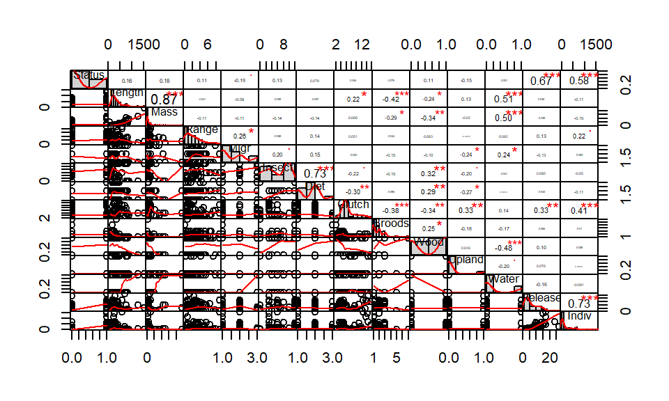

```r
#Examining correlations among variables (Pearson or Spearman)
#library(PerformanceAnalytics)
chart.Correlation(Data.num,
                  method="spearman",
                  histogram=TRUE,
                  pch=16)
```

Another approach is to examine the correlation coefficients directly

```r
#library(psych)
corr.test(Data.num,
          use = "pairwise",
          method="spearman",
          adjust="none",      # Can adjust p-values; see ?p.adjust for options
          alpha=.05)
```

```
## Call:corr.test(x = Data.num, use = "pairwise", method = "spearman",
##     adjust = "none", alpha = 0.05)
## Correlation matrix
##         Status Length  Mass Range  Migr Insect  Diet Clutch Broods  Wood
## Status    1.00   0.09  0.03  0.15 -0.14   0.14  0.08  -0.06  -0.03  0.11
## Length    0.09   1.00  0.91  0.01 -0.06   0.04  0.11   0.27  -0.68 -0.18
## Mass      0.03   0.91  1.00 -0.14 -0.20  -0.12  0.00   0.34  -0.66 -0.33
## Range     0.15   0.01 -0.14  1.00  0.40   0.03  0.12   0.09   0.00  0.11
## Migr     -0.14  -0.06 -0.20  0.40  1.00   0.19  0.18   0.04  -0.04 -0.08
## Insect    0.14   0.04 -0.12  0.03  0.19   1.00  0.77  -0.33  -0.09  0.32
## Diet      0.08   0.11  0.00  0.12  0.18   0.77  1.00  -0.36  -0.08  0.30
## Clutch   -0.06   0.27  0.34  0.09  0.04  -0.33 -0.36   1.00  -0.37 -0.40
## Broods   -0.03  -0.68 -0.66  0.00 -0.04  -0.09 -0.08  -0.37   1.00  0.27
## Wood      0.11  -0.18 -0.33  0.11 -0.08   0.32  0.30  -0.40   0.27  1.00
## Upland   -0.15   0.19  0.20 -0.02 -0.25  -0.21 -0.27   0.34  -0.22  0.05
## Water    -0.05   0.45  0.49  0.07  0.21  -0.03  0.00   0.20  -0.33 -0.48
## Release   0.70   0.05  0.00  0.17 -0.06   0.10 -0.05   0.15  -0.02  0.13
## Indiv     0.66  -0.07 -0.13  0.19 -0.13   0.00 -0.11   0.14   0.08  0.10
##         Upland Water Release Indiv
## Status   -0.15 -0.05    0.70  0.66
## Length    0.19  0.45    0.05 -0.07
## Mass      0.20  0.49    0.00 -0.13
## Range    -0.02  0.07    0.17  0.19
## Migr     -0.25  0.21   -0.06 -0.13
## Insect   -0.21 -0.03    0.10  0.00
## Diet     -0.27  0.00   -0.05 -0.11
## Clutch    0.34  0.20    0.15  0.14
## Broods   -0.22 -0.33   -0.02  0.08
## Wood      0.05 -0.48    0.13  0.10
## Upland    1.00 -0.20    0.06  0.02
## Water    -0.20  1.00   -0.11 -0.16
## Release   0.06 -0.11    1.00  0.88
## Indiv     0.02 -0.16    0.88  1.00
## Sample Size
##         Status Length Mass Range Migr Insect Diet Clutch Broods Wood
## Status      79     79   74    79   79     77   79     79     74   79
## Length      79     79   74    79   79     77   79     79     74   79
## Mass        74     74   74    74   74     72   74     74     71   74
## Range       79     79   74    79   79     77   79     79     74   79
## Migr        79     79   74    79   79     77   79     79     74   79
```

[output cut: 42 more lines]

```
## Length    0.09  0.00    0.64  0.56
## Mass      0.08  0.00    0.98  0.26
## Range     0.88  0.55    0.13  0.10
## Migr      0.03  0.06    0.57  0.25
## Insect    0.06  0.77    0.39  0.99
## Diet      0.01  0.97    0.69  0.32
## Clutch    0.00  0.08    0.17  0.23
## Broods    0.06  0.00    0.85  0.51
## Wood      0.69  0.00    0.25  0.41
## Upland    0.00  0.08    0.58  0.87
## Water     0.08  0.00    0.35  0.17
## Release   0.58  0.35    0.00  0.00
## Indiv     0.87  0.17    0.00  0.00
##
##  To see confidence intervals of the correlations, print with the short=FALSE option
```

### Missing Data

Missing data can severely affect the performance and reliability of logistic regression models. A missing data plot can be used to get a quick idea of the amount of missing data in the dataset. The x-axis shows attributes (i.e., covariates) and the y-axis shows instances (i.e., observations or individuals). Horizontal lines indicate missing data for an instance, vertical blocks represent missing data for an attribute.

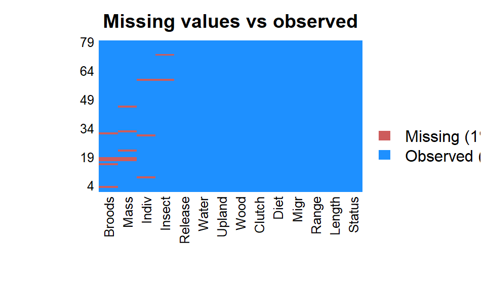

```r
Amelia::missmap(Data.num, main = "Missing values vs observed")
```

### Remove missing data

```r
Data.omit = na.omit(Data.num)
```

### Simple Logistic Regression Example

```r
model.simple = glm(Status ~ Release,
                 data=Data.omit,
                 family = binomial(link="logit")
                 )

summary(model.simple)
```

```
##
## Call:
## glm(formula = Status ~ Release, family = binomial(link = "logit"),
##     data = Data.omit)
##
## Deviance Residuals:
##     Min       1Q   Median       3Q      Max
## -3.2454  -0.5745  -0.4202   0.5188   1.9407
##
## Coefficients:
##             Estimate Std. Error z value Pr(>|z|)
## (Intercept) -2.71511    0.61118  -4.442 8.90e-06 ***
## Release      0.33234    0.07554   4.400 1.08e-05 ***
## ---
## Signif. codes:  0 '***' 0.001 '**' 0.01 '*' 0.05 '.' 0.1 ' ' 1
##
## (Dispersion parameter for binomial family taken to be 1)
##
##     Null deviance: 90.343  on 66  degrees of freedom
## Residual deviance: 56.130  on 65  degrees of freedom
## AIC: 60.13
##
## Number of Fisher Scoring iterations: 5
```

In the output above, the ‘call’ is R reminding us what model was ran, what options we specified, etc.

The deviance residuals, are a measure of model fit. This part of output shows the distribution of the deviance residuals for individual cases used in the model.

The next part of the output shows (1) the coefficients, (2) their standard errors, (3) the z-statistic (sometimes called a Wald z-statistic), and (4) the associated p-values.

The logistic regression coefficients give the change in the log odds of the outcome for a one unit increase in the predictor variable.

```
For example: every unit change in 'Release', the log odds of establishment (versus non-establishment) increases by 0.33234.
```

Below the table of coefficients are fit indices, including the null and deviance residuals and the AIC. These values can be used to help assess model fit.

### Model significance testing

The wald.test() function. (1) b supplies the coefficients, (2) Sigma supplies the variance covariance matrix of the error terms, (3) Terms tells R which terms in the model are to be tested (in this case only 1)

```r
aod::wald.test(b = coef(model.simple), Sigma = vcov(model.simple), Terms = 1)
```

```
## Wald test:
## ----------
##
## Chi-squared test:
## X2 = 19.7, df = 1, P(> X2) = 8.9e-06
```

### Odds ratio

Odds-ratios can be calculated by exponentiating the modely coefficients

```r
## odds ratios only
exp(coef(model.simple))
```

```
## (Intercept)     Release
##   0.0661979   1.3942287
```

The same logic can be used to get odds ratios and their confidence intervals.

```r
## odds ratios and 95% CI
exp(cbind(OR = coef(model.simple), confint(model.simple)))
```

```
##                    OR      2.5 %    97.5 %
## (Intercept) 0.0661979 0.01715994 0.1956924
## Release     1.3942287 1.22088717 1.6479282
```

This shows that a one unit increase in ‘Release’ increases the odds of becoming established in New Zealand (versus not establishing) by a factor of 1.39.

### Assessing Model fit

One measure of model fit is to test whether the model with predictors fits significantly better than a model with just an intercept (i.e., a null model). The test statistic is the difference between the residual deviance for the model with predictors and the null model. The test statistic has a chi-squared distribution with the degrees of freedom equal to the differences in degrees of freedom between the current and the null model (i.e., the number of predictor variables in the model). To find the difference in deviance for the two models (i.e., the test statistic) we can use the command:

```r
with(model.simple, pchisq(null.deviance - deviance, df.null - df.residual, lower.tail = FALSE))
```

```
## [1] 4.939945e-09
```

The chi-square of 34.21 with 1 degrees of freedom and an associated p-value of 4.939945e-09 tells us that our model as a whole fits significantly better than an empty (NULL)model.

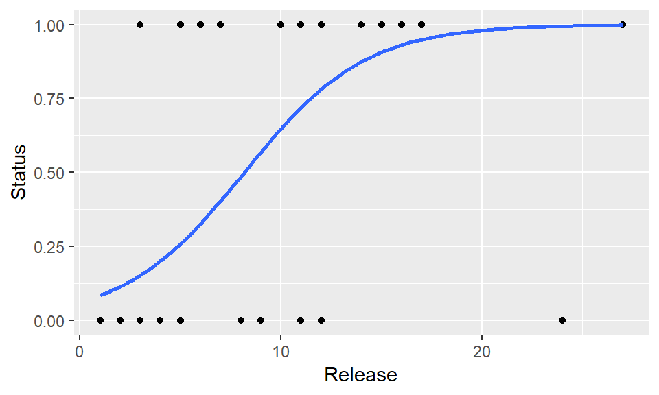

```r
library(ggplot2)
ggplot(Data.omit, aes(x=Release, y=Status)) + geom_point() +
  stat_smooth(method="glm", method.args=list(family="binomial"), se=FALSE)
```

### Reciever Operating Characteristics (ROC)

ROC curves provide a graphical representation of classifier performance. The ROC curve is a two-dimensional plot with sensitivity on the Y axis, 1 -Specificity on the X axis.

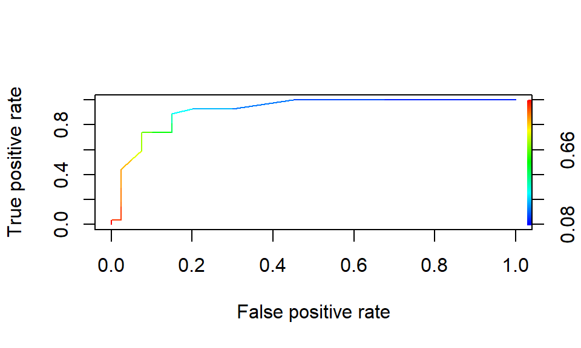

```r
#ROCR Curve
library(ROCR)

predicted <- predict(model.simple, type = 'response')

ROCRpred <- prediction(predicted, Data.omit$Status)
ROCRperf <- performance(ROCRpred, 'tpr','fpr')
plot(ROCRperf, colorize = TRUE, text.adj = c(-0.2,1.7))
```

### Area under the curve (AUC)

The AUC is defined as the probability that the fit model will score a randomly drawn positive sample higher than a randomly drawn negative sample. AUC ranges between 0 and 1. A higher AUC values indicates a more powerful classifier (Assuming the general shape of the ROC curves remains relative constant)

```r
# Outcome Flag & Predicted probability

cvAUC::AUC(predicted, Data.omit$Status, label.ordering = NULL)
```

```
## [1] 0.9148148
```

### Multiple logistic regression

The New Zealand bird data will be extended to include multiple predictor variables (i.e., independent variables). Missing data can be problematic for multiple logistic regression. The method for handle missing values in a multiple regression is to remove all observations from the data set that have any missing values (e.g., data frame called Data.omit).

```r
### Create new data frame with all missing values removed (NA’s)

Data.omit = na.omit(Data.num)
```

### Variable selection procedure

There are two main approaches towards variable selection: the all possible regressions approach (or multiple working hypotheses) and automatic methods. Automatic methods are useful when the number of explanatory variables is large and it is not feasible to fit all possible models. Automatic methods use a search algorithm (e.g., Forward selection, Backward elimination and Stepwise regression) to find the best model. To perform forward selection we need to begin by specifying a starting model and the range of models which we want to examine in the search. The R function step() can be used to perform variable selection.

```r
### Define full and null models and do step procedure

model.null = glm(Status ~ 1,
                 data=Data.omit,
                 family = binomial(link="logit")
                 )

model.full = glm(Status ~ Length + Mass + Range + Migr + Insect + Diet +
                          Clutch + Broods + Wood + Upland + Water +
                          Release + Indiv,
                 data=Data.omit,
                 family = binomial(link="logit")
                 )

step(model.null,
     scope = list(upper=model.full),
             direction="both",
             test="Chisq",
             data=Data.omit)
```

```
## Start:  AIC=92.34
## Status ~ 1
##
##           Df Deviance    AIC    LRT  Pr(>Chi)
## + Release  1   56.130 60.130 34.213 4.940e-09 ***
## + Indiv    1   60.692 64.692 29.651 5.172e-08 ***
## + Migr     1   85.704 89.704  4.639   0.03125 *
## + Upland   1   86.987 90.987  3.356   0.06696 .
## + Insect   1   88.231 92.231  2.112   0.14614
## <none>         90.343 92.343
## + Mass     1   88.380 92.380  1.963   0.16121
## + Wood     1   88.781 92.781  1.562   0.21133
## + Diet     1   89.195 93.195  1.148   0.28394
## + Length   1   89.372 93.372  0.972   0.32430
## + Water    1   90.104 94.104  0.240   0.62448
## + Broods   1   90.223 94.223  0.120   0.72898
## + Range    1   90.255 94.255  0.088   0.76676
## + Clutch   1   90.332 94.332  0.012   0.91420
## ---
## Signif. codes:  0 '***' 0.001 '**' 0.01 '*' 0.05 '.' 0.1 ' ' 1
##
## Step:  AIC=60.13
## Status ~ Release
##
##           Df Deviance    AIC    LRT Pr(>Chi)
## + Upland   1   48.024 54.024  8.106 0.004412 **
## + Clutch   1   51.877 57.877  4.253 0.039182 *
## + Mass     1   52.052 58.052  4.078 0.043445 *
## + Migr     1   53.309 59.309  2.821 0.093040 .
## + Length   1   53.696 59.696  2.435 0.118672
## <none>         56.130 60.130
## + Diet     1   54.307 60.307  1.823 0.176949
## + Insect   1   55.157 61.157  0.973 0.323855
## + Indiv    1   55.273 61.273  0.858 0.354425
## + Water    1   55.649 61.649  0.482 0.487602
## + Broods   1   55.746 61.746  0.384 0.535397
## + Wood     1   55.883 61.883  0.247 0.619195
## + Range    1   56.045 62.045  0.085 0.770551
## - Release  1   90.343 92.343 34.213 4.94e-09 ***
## ---
```

[output cut: 133 more lines]

```
## - Wood     1   30.710 42.710  2.679  0.101686
## + Diet     1   26.960 42.960  1.071  0.300673
## + Length   1   27.965 43.965  0.066  0.796641
## + Water    1   27.970 43.970  0.062  0.803670
## + Broods   1   27.983 43.983  0.048  0.825974
## + Clutch   1   28.005 44.005  0.027  0.870592
## + Release  1   28.009 44.009  0.022  0.881631
## + Range    1   28.031 44.031  0.000  0.999964
## - Insect   1   32.369 44.369  4.338  0.037276 *
## - Migr     1   35.169 47.169  7.137  0.007550 **
## - Upland   1   38.302 50.302 10.270  0.001352 **
## - Mass     1   43.402 55.402 15.371 8.833e-05 ***
## - Indiv    1   71.250 83.250 43.219 4.894e-11 ***
## ---
## Signif. codes:  0 '***' 0.001 '**' 0.01 '*' 0.05 '.' 0.1 ' ' 1
```

```
##
## Call:  glm(formula = Status ~ Upland + Migr + Mass + Indiv + Insect +
##     Wood, family = binomial(link = "logit"), data = Data.omit)
##
## Coefficients:
## (Intercept)       Upland         Migr         Mass        Indiv
##   -3.437608    -4.730656    -2.023985     0.001939     0.013812
##      Insect         Wood
##    0.270468     1.948944
##
## Degrees of Freedom: 66 Total (i.e. Null);  60 Residual
## Null Deviance:       90.34
## Residual Deviance: 28.03     AIC: 42.03
```

According to this procedure, the best model is the one that includes the variables: Upland, Migr, Mass, Indiv, Insect, and Wood

### Final Model Data

In the final model, it is important to exclude only those observations that have missing values in the variables that are actually included in the final model. For testing the overall p-value of the final model, plotting the final model, or using the glm.compare function, we will create a data frame with only those observations excluded (i.e., data frame called Data.final).

```r
Data.final <-
   select(Data.num,
          Status,
          Upland,
          Migr,
          Mass,
          Indiv,
          Insect,
          Wood)

Data.final <- na.omit(Data.final)
```

```r
#Final Model

model.final = glm(Status ~ Upland + Migr + Mass + Indiv + Insect + Wood,
                  data=Data.final,
                  family = binomial(link="logit")
                  )

summary(model.final)
```

```
##
## Call:
## glm(formula = Status ~ Upland + Migr + Mass + Indiv + Insect +
##     Wood, family = binomial(link = "logit"), data = Data.final)
##
## Deviance Residuals:
##     Min       1Q   Median       3Q      Max
## -1.5312  -0.3128  -0.0971   0.1435   2.5768
##
## Coefficients:
##               Estimate Std. Error z value Pr(>|z|)
## (Intercept) -3.5496482  2.0827400  -1.704 0.088322 .
## Upland      -4.5484289  2.0712502  -2.196 0.028093 *
## Migr        -1.8184049  0.8325702  -2.184 0.028956 *
## Mass         0.0019029  0.0007048   2.700 0.006940 **
## Indiv        0.0137061  0.0038703   3.541 0.000398 ***
## Insect       0.2394720  0.1373456   1.744 0.081234 .
## Wood         1.8134445  1.3105911   1.384 0.166455
## ---
## Signif. codes:  0 '***' 0.001 '**' 0.01 '*' 0.05 '.' 0.1 ' ' 1
##
## (Dispersion parameter for binomial family taken to be 1)
##
##     Null deviance: 93.351  on 69  degrees of freedom
## Residual deviance: 30.392  on 63  degrees of freedom
## AIC: 44.392
##
## Number of Fisher Scoring iterations: 7
```

In the output above, the ‘call’ is R reminding us what model was ran, what options we specified, etc.

The deviance residuals, are a measure of model fit. This part of output shows the distribution of the deviance residuals for individual cases used in the model.

The next part of the output shows (1) the coefficients, (2) their standard errors, (3) the z-statistic (sometimes called a Wald z-statistic), and (4) the associated p-values.

The logistic regression coefficients give the change in the log odds of the outcome for a one unit increase in the predictor variable.

### Assessing significance of model covariates

Another way to overall effect of retained predictor variables is using the Wald test (results similar to those shown above).

```r
#Analysis of variance for individual terms

car::Anova(model.final, type="II", test="Wald")
```

```
## Analysis of Deviance Table (Type II tests)
##
## Response: Status
##        Df   Chisq Pr(>Chisq)
## Upland  1  4.8223  0.0280932 *
## Migr    1  4.7702  0.0289559 *
## Mass    1  7.2883  0.0069404 **
## Indiv   1 12.5412  0.0003981 ***
## Insect  1  3.0400  0.0812336 .
## Wood    1  1.9146  0.1664551
## ---
## Signif. codes:  0 '***' 0.001 '**' 0.01 '*' 0.05 '.' 0.1 ' ' 1
```

### Pseudo-R-squared

R does not produce r-squared values for generalized linear models (glm) to assess model fit. Instead, psuedo-R-squared values can be generated that to provide information similar to that provided by R-squared in OLS regression; however, psuedo-R-squared values cannot be interpretated exactly as R-squared in OLS regression. These pseudo-R-squared values compare the maximum likelihood of the model to a nested null model fit with the same method. They should be interpreted as a relative measure among similar models.

```r
#Pseudo-R-squared

rcompanion::nagelkerke(model.final)
```

```
## $Models
##
## Model: "glm, Status ~ Upland + Migr + Mass + Indiv + Insect + Wood, binomial(link = \"logit\"), Data.final"
## Null:  "glm, Status ~ 1, binomial(link = \"logit\"), Data.final"
##
## $Pseudo.R.squared.for.model.vs.null
##                              Pseudo.R.squared
## McFadden                             0.674430
## Cox and Snell (ML)                   0.593190
## Nagelkerke (Cragg and Uhler)         0.805452
##
## $Likelihood.ratio.test
##  Df.diff LogLik.diff  Chisq    p.value
##       -6     -31.479 62.959 1.1254e-11
##
## $Number.of.observations
##
## Model: 70
## Null:  70
##
## $Messages
## [1] "Note: For models fit with REML, these statistics are based on refitting with ML"
##
## $Warnings
## [1] "None"
```

### Testing overall model fit

Note that testing p-values for a logistic regression uses a Chi-square tests to evaluate the significance of the overall model.

```r
### Define null models and compare to final model

model.null = glm(Status ~ 1,
                  data=Data.final,
                  family = binomial(link="logit")
                  )

anova(model.final, model.null, test="Chisq")
```

```
## Analysis of Deviance Table
##
## Model 1: Status ~ Upland + Migr + Mass + Indiv + Insect + Wood
## Model 2: Status ~ 1
##   Resid. Df Resid. Dev Df Deviance  Pr(>Chi)
## 1        63     30.392
## 2        69     93.351 -6  -62.959 1.125e-11 ***
## ---
## Signif. codes:  0 '***' 0.001 '**' 0.01 '*' 0.05 '.' 0.1 ' ' 1
```

### Likelihood ratio test

A likelihood ratio test can also be used to test the significance of the overall model

```r
lrtest(model.final)
```

```
## Likelihood ratio test
##
## Model 1: Status ~ Upland + Migr + Mass + Indiv + Insect + Wood
## Model 2: Status ~ 1
##   #Df  LogLik Df  Chisq Pr(>Chisq)
## 1   7 -15.196
## 2   1 -46.675 -6 62.959  1.125e-11 ***
## ---
## Signif. codes:  0 '***' 0.001 '**' 0.01 '*' 0.05 '.' 0.1 ' ' 1
```

A plot of standardized residuals vs. predicted values. The residuals should be unbiased and homoscedastic.

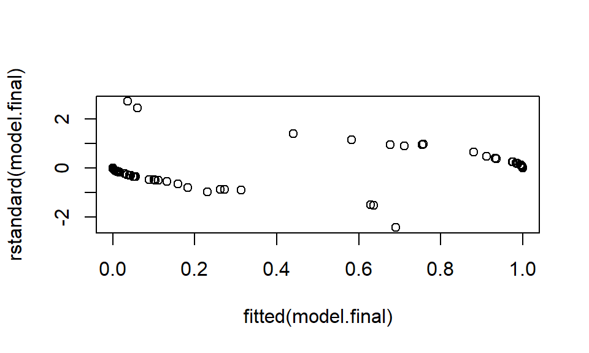

```r
#Plot of standardized residuals


plot(fitted(model.final),
     rstandard(model.final))
```

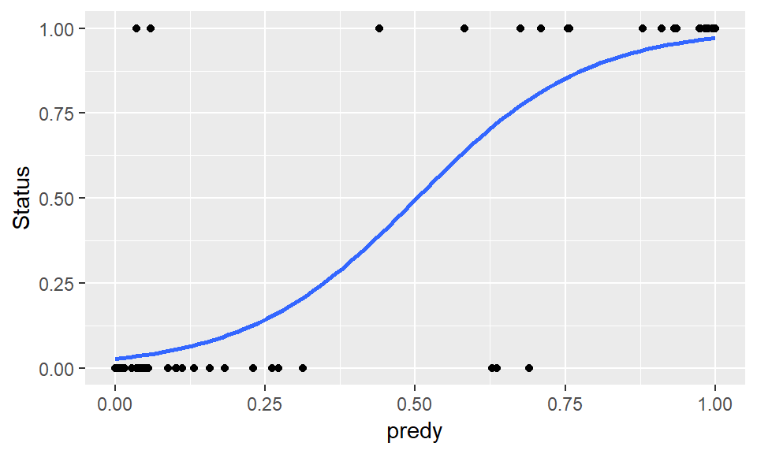

```r
#Simple plot of predicted values

Data.final =
   select(Data.num,
          Status,
          Upland,
          Migr,
          Mass,
          Indiv,
          Insect,
          Wood)

Data.final = na.omit(Data.final)

Data.final$predy = predict(model.final, type="response")


### Plot

library(ggplot2)
ggplot(Data.final, aes(x=predy, y=Status)) + geom_point() +
  stat_smooth(method="glm", method.args=list(family="binomial"), se=FALSE)
```

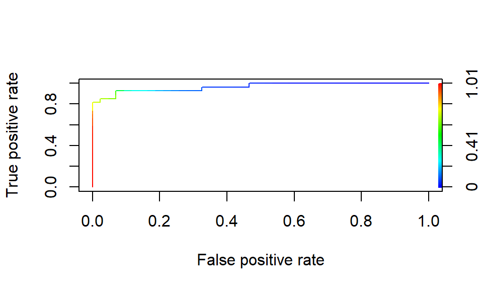

```r
#ROCR Curve
library(ROCR)
ROCRpred.final <- prediction(Data.final$predy, Data.final$Status)
ROCRperf.final <- performance(ROCRpred.final, 'tpr','fpr')
plot(ROCRperf.final, colorize = TRUE, text.adj = c(-0.2,1.7))
```

### Overdispersion

Is an indication that the model doesn’t fit the data well. Overdispersion is a situation where the residual deviance of the glm is large relative to the residual degrees of freedom. These values are shown in the summary of the model. One guideline is that if the ratio of the residual deviance to the residual degrees of freedom exceeds 1.5, then the model is overdispersed.

```r
summary(model.final)$deviance/summary(model.final)$df.residual
```

```
## [1] 0.482417
```

### Linear Discriminant Analysis (LDA)

The LDA aims to identify linear combinations of predictor variables that maximize the separation between classes, then use these linear discrimants to predict the class of individuals. LDA assumes that predictors are normally distributed (Gaussian distribution) and that the different classes have class-specific means and equal variance/covariance.

Iris data:

Goal: predicting iris species based on the predictor variables Sepal.Length, Sepal.Width, Petal.Length, Petal.Width.

```r
library(tidyverse)
library(caret)
library(klaR)
data(iris)
head(iris)
```

```
##   Sepal.Length Sepal.Width Petal.Length Petal.Width Species
## 1          5.1         3.5          1.4         0.2  setosa
## 2          4.9         3.0          1.4         0.2  setosa
## 3          4.7         3.2          1.3         0.2  setosa
## 4          4.6         3.1          1.5         0.2  setosa
## 5          5.0         3.6          1.4         0.2  setosa
## 6          5.4         3.9          1.7         0.4  setosa
```

### Training vs Test data

To generate a LDA model and evaluate its performance requires the available data to be separated into training and test data.

```r
# Split the data into training (80%) and test set (20%)
set.seed(123)

training.samples <- iris$Species %>% createDataPartition(p = 0.8, list = FALSE)

train.data <- iris[training.samples, ]
test.data <- iris[-training.samples, ]
```

### Assumption of LDA

Inspecting the univariate distributions of each variable and make sure that they are normally distribute. If not, you can transform them using log and root for exponential distributions and Box-Cox for skewed distributions.

It is generally recommended to standardize/normalize continuous predictors before the analysis since discriminant analysis can be affected by the scale/unit in which predictor variables are measured, and also outliers should be removed.

```r
# Estimate preprocessing parameters
preproc.param <- train.data %>% preProcess(method = c("center", "scale"))

# Transform the data using the estimated parameters
train.transformed <- preproc.param %>% predict(train.data)
test.transformed <- preproc.param %>% predict(test.data)
```

### Specifying the LDA Model

```r
library(MASS)
model.lda <- lda(Species~., data = train.transformed)
model.lda
```

```
## Call:
## lda(Species ~ ., data = train.transformed)
##
## Prior probabilities of groups:
##     setosa versicolor  virginica
##  0.3333333  0.3333333  0.3333333
##
## Group means:
##            Sepal.Length Sepal.Width Petal.Length Petal.Width
## setosa       -1.0120728   0.7867793   -1.2927218  -1.2496079
## versicolor    0.1174121  -0.6478157    0.2724253   0.1541511
## virginica     0.8946607  -0.1389636    1.0202965   1.0954568
##
## Coefficients of linear discriminants:
##                     LD1         LD2
## Sepal.Length  0.9108023  0.03183011
## Sepal.Width   0.6477657  0.89852536
## Petal.Length -4.0816032 -2.22724052
## Petal.Width  -2.3128276  2.65441936
##
## Proportion of trace:
##    LD1    LD2
## 0.9905 0.0095
```

LDA determines group means and for each individual computes the probability of belonging to the different groups. The individual is then assigned to the group with the highest probability score.

LDA output:

1. Prior probabilities of groups: the proportion of training observations in each group (e.g., 33% of the training observations in the setosa group)
2. Group means: group center of gravity or mean of each variable in each group.
3. Coefficients of linear discriminants: linear combination of predictor variables used to form the LDA decision rule.

### Two-dimensional Plot of linear discriminants

Linear discriminants are plotted using values of LD1 and LD2 for each of the training observations.

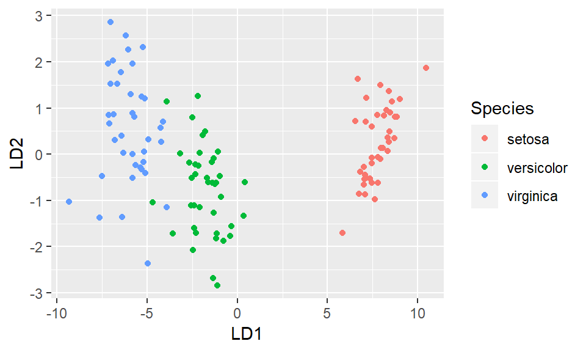

```r
lda.data <- cbind(train.transformed, predict(model.lda)$x)
ggplot(lda.data, aes(LD1, LD2)) + geom_point(aes(color = Species))
```

As you can see, there are three distinct groups with some overlap between virginica and versicolor. Plotting again, but adding the code dimen = 1 will only plot in one dimension (LD1). Think of it as a projection of the data onto LD1 with a histogram of that data.

### One-dimensional plot of linear discriminants

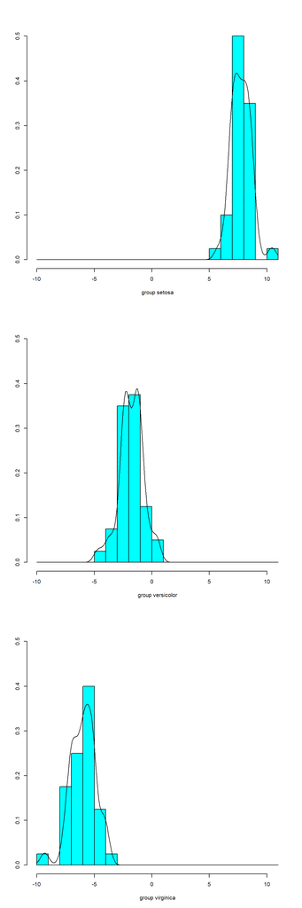

```r
plot(model.lda, dimen = 1, type = "b")
```

These plots illustrate the separation between groups as well as overlapping areas that are potential for mix-ups when predicting classes.

### LDA Partition Plots

An alternate way to plot the linear discriminant functions is to produce an array of plots for every combination of two variables. Colored regions delineate each classification area and any observation that falls within a region is predicted to be from a specific class. Each plot also includes the apparent error rate for that view of the data.

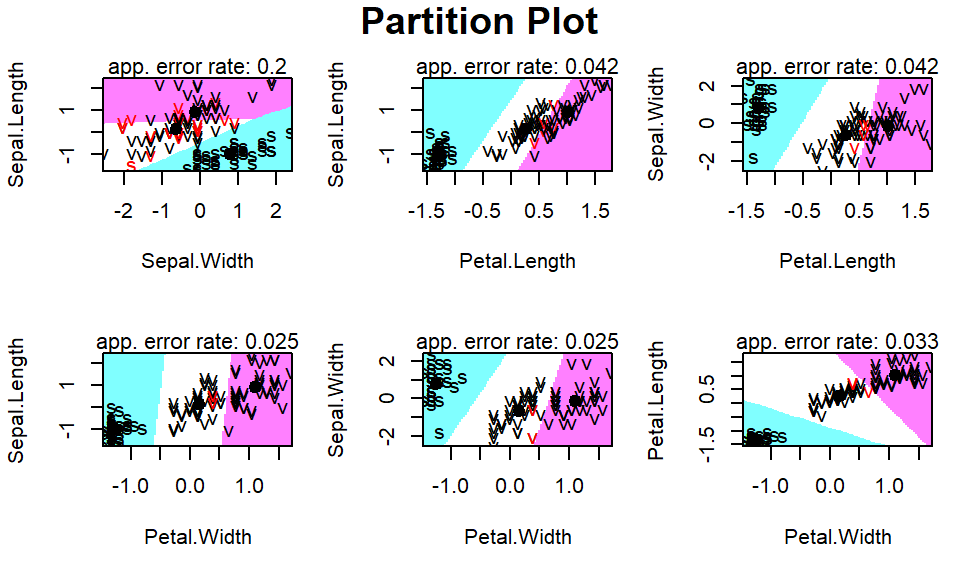

```r
partimat(Species ~ Sepal.Length + Sepal.Width + Petal.Length + Petal.Width, data=train.transformed, method="lda")
```

### Confusion matrix

```r
lda.train <- predict(model.lda)
train.transformed$lda <- lda.train$class
table(train.transformed$lda,train.transformed$Species)
```

```
##
##              setosa versicolor virginica
##   setosa         40          0         0
##   versicolor      0         38         1
##   virginica       0          2        39
```

The total number of correctly predicted observations is the sum of the diagonal.Based on the earlier plots, it makes sense that a few iris versicolor and iris virginica observations may be miscategorized.

### Assess model performance

The test set is run against the model to determine its accuracy.

```r
lda.test <- predict(model.lda,test.transformed)
test.transformed$lda <- lda.test$class
table(test.transformed$lda,test.transformed$Species)
```

```
##
##              setosa versicolor virginica
##   setosa         10          0         0
##   versicolor      0         10         0
##   virginica       0          0        10
```

Overall the model performs very well with the testing set with an accuracy of 100%.

### Overall Model Accuracy:

You can compute the overall model accuracy (x100).

```r
mean(lda.test$class==test.transformed$Species)
```

```
## [1] 1
```

The model correctly classified 100% of observations.

# Prediction: Test data

Information can be extracted for each individuals in the test data set regarding their class assignment

```r
predictions <- model.lda %>% predict(test.transformed)

# Predicted classes
head(predictions$class, 6)
```

```
## [1] setosa setosa setosa setosa setosa setosa
## Levels: setosa versicolor virginica
```

```r
# Predicted probabilities of class memebership.
tail(predictions$posterior, 6)
```

```
##           setosa   versicolor virginica
## 130 4.936566e-33 2.030434e-01 0.7969566
## 131 3.706400e-43 1.447420e-04 0.9998553
## 135 3.744023e-37 6.646693e-02 0.9335331
## 137 4.629164e-47 1.068241e-07 0.9999999
## 145 1.142306e-48 3.380131e-08 1.0000000
## 148 1.327276e-36 1.436760e-03 0.9985632
```

```r
# Linear discriminants
head(predictions$x, 3)
```

```
##         LD1        LD2
## 5  8.495822  0.7032086
## 6  8.095995  1.6969837
## 10 7.667684 -0.8766525
```

The output returns the following elements:

1. The predicted classes of observations (i.e., assigned species name)
2. The posterior probability that the corresponding observation belongs to the groups (columns are the groups, rows are the individuals and values are posterior probabilities)
3. Linear discriminants (e.g., used for plotting)

### Quadratic discriminant analysis - QDA

Quadratic discriminant analysis is a modification of LDA that does not assume equal covariance matrices amongst the groups (i.e., the covariance matrix can be different for each class). QDA is recommended if the training set is very large, or if the assumption of a common covariance matrix for the K classes is clearly not met.

```r
#library(MASS)

# Fit the model
model.qda <- qda(Species~Sepal.Length+Sepal.Width+Petal.Length+Petal.Width, data = train.transformed)
model.qda
```

```
## Call:
## qda(Species ~ Sepal.Length + Sepal.Width + Petal.Length + Petal.Width,
##     data = train.transformed)
##
## Prior probabilities of groups:
##     setosa versicolor  virginica
##  0.3333333  0.3333333  0.3333333
##
## Group means:
##            Sepal.Length Sepal.Width Petal.Length Petal.Width
## setosa       -1.0120728   0.7867793   -1.2927218  -1.2496079
## versicolor    0.1174121  -0.6478157    0.2724253   0.1541511
## virginica     0.8946607  -0.1389636    1.0202965   1.0954568
```

```r
# Make predictions
predictions.qda <- model.qda %>% predict(test.transformed)

# Model accuracy
mean(predictions.qda$class == test.transformed$Species)
```

```
## [1] 1
```

### QDA Partition Plots

Plotting the the quadratic discriminant functions using partition plots provides a good way visualize the difference between the linear functions used in LDA and the quadratic functions used in QDA. The colored regions delineate each classification area. Observations that fall within a region is predicted to be from that specific class. Each plot also includes the apparent error rate for that view of the data.

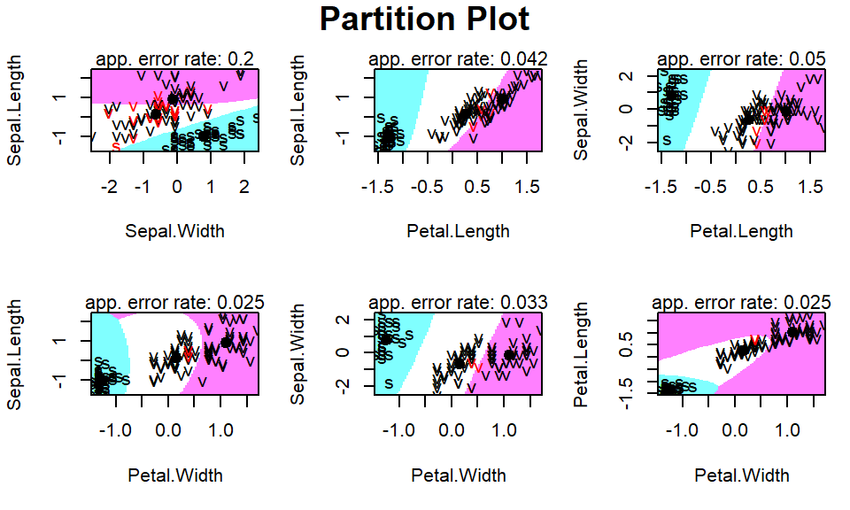

```r
partimat(Species~Sepal.Length+Sepal.Width+Petal.Length+Petal.Width, data = train.transformed, method="qda")
```

# QDA confusion matrix

The predict function works exactly the same way as before and can be used to create a confusion matrix for the training data.

```r
qda.train <- predict(model.qda)
train.transformed$qda <- qda.train$class
table(train.transformed$qda,train.transformed$Species)
```

```
##
##              setosa versicolor virginica
##   setosa         40          0         0
##   versicolor      0         38         1
##   virginica       0          2        39
```

This model fit the training data very well.

### QDA Model Performance

The test set is run against the model to determine its accuracy.

```r
qda.test <- predict(model.qda,test.transformed)
test.transformed$qda <- qda.test$class
table(test.transformed$qda,test.transformed$Species)
```

```
##
##              setosa versicolor virginica
##   setosa         10          0         0
##   versicolor      0         10         0
##   virginica       0          0        10
```

The model correctly predicted the class of observations 100% of the time.

### K-Nearest Neighbor (KNN)

KNN is a non-parametric supervised learning technique in which we try to classify the data point to a given category with the help of training set. More simply, it captures information of all training cases and classifies new cases based on a similarity. Predictions are made for a new instance (x) by searching through the entire training set for the K most similar cases (neighbors) and summarizing the output variable for those K cases (i.e., based on the mode or most common class value).

```r
head(iris)
```

```
##   Sepal.Length Sepal.Width Petal.Length Petal.Width Species
## 1          5.1         3.5          1.4         0.2  setosa
## 2          4.9         3.0          1.4         0.2  setosa
## 3          4.7         3.2          1.3         0.2  setosa
## 4          4.6         3.1          1.5         0.2  setosa
## 5          5.0         3.6          1.4         0.2  setosa
## 6          5.4         3.9          1.7         0.4  setosa
```

Standardization

When independent variables in training data are measured in different units, it is important to standardize variables before calculating distance.

```r
##Generate a random number that is 80% of the total number of rows in dataset.
 ran <- sample(1:nrow(iris), 0.8 * nrow(iris))

 ##the normalization function is created
 nor <-function(x) {
   (x-min(x))/(max(x)-min(x))
   }

 ##Run nomalization on first 4 coulumns of dataset because they are the predictors
 iris_norm <- as.data.frame(lapply(iris[,-5], nor))

 summary(iris_norm)
```

```
##   Sepal.Length     Sepal.Width      Petal.Length     Petal.Width
##  Min.   :0.0000   Min.   :0.0000   Min.   :0.0000   Min.   :0.00000
##  1st Qu.:0.2222   1st Qu.:0.3333   1st Qu.:0.1017   1st Qu.:0.08333
##  Median :0.4167   Median :0.4167   Median :0.5678   Median :0.50000
##  Mean   :0.4287   Mean   :0.4406   Mean   :0.4675   Mean   :0.45806
##  3rd Qu.:0.5833   3rd Qu.:0.5417   3rd Qu.:0.6949   3rd Qu.:0.70833
##  Max.   :1.0000   Max.   :1.0000   Max.   :1.0000   Max.   :1.00000
```

The “k” is the number of neighbors that knn uses to determine what class to label an unknown example. The number of “k” to use can vary but a rule of thumb is to take the square root of the total number of observations in the training data (e.g., k=11)

```r
##extract training set
iris_train <- iris_norm[ran,]

##extract testing set
 iris_test <- iris_norm[-ran,]

 ##extract 5th column of train dataset because it will be used as 'cl' argument in knn function.
 iris_target_category <- iris[ran,5]

 ##extract 5th column if test dataset to measure the accuracy
 iris_test_category <- iris[-ran,5]

##load the package class
 library(class)

 ##run knn function
 pr <- knn(iris_train,iris_test,cl=iris_target_category,k=11)

 ##create confusion matrix
 tab <- table(pr,iris_test_category)
 tab
```

```
##             iris_test_category
## pr           setosa versicolor virginica
##   setosa          6          0         0
##   versicolor      0          8         1
##   virginica       0          1        14
```

```r
 ##this function divides the correct predictions by total number of predictions that tell us how accurate teh model is.

 accuracy <- function(x){sum(diag(x)/(sum(rowSums(x)))) * 100}
 accuracy(tab)
```

```
## [1] 93.33333
```

### KNN plot

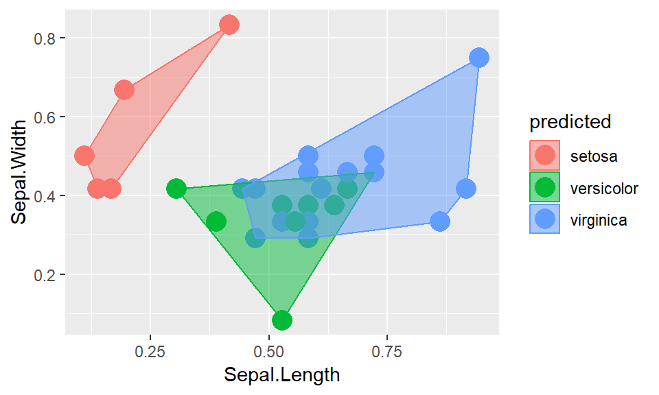

```r
#library(class)
#library(ggplot2)

# Do knn
fit = knn(iris_train,iris_test,cl=iris_target_category,k=11)

# Create a dataframe to simplify charting
plot.df = data.frame(iris_test, predicted = fit)

# Use ggplot
# 2-D plots example only
# Sepal.Length vs Sepal.Width

# First use Convex hull to determine boundary points of each cluster
plot.df1 = data.frame(x = plot.df$Sepal.Length,
                      y = plot.df$Sepal.Width,
                      predicted = plot.df$predicted)

find_hull = function(df) df[chull(df$x, df$y), ]
boundary = plyr::ddply(plot.df1, .variables = "predicted", .fun = find_hull)

ggplot(plot.df, aes(Sepal.Length, Sepal.Width, color = predicted, fill = predicted)) +
  geom_point(size = 5) +
  geom_polygon(data = boundary, aes(x,y), alpha = 0.5)
```